# Lead IQ Report

Siyang Ren

2024-10-08

## Introduction

This report provides an analysis of the dataset “lead-iq-01.csv,” which contains information about IQ levels of children aged 3 to 15 in El Paso, who lived at various distances from a large lead-emitting ore smelter. Lead exposure is known to affect neurological function, and this dataset captures IQ scores of children based on their proximity to the smelter. The dataset includes the columns:

- **Smelter**: Categorical variable indicating whether the subject lived “Near” or “Far” from the lead smelter.
- **IQ**: Numerical variable representing the IQ score as measured by the Wechsler Intelligence Scale for Children (WISC).

We will explore the data using visualizations and descriptive statistics. Note that after discussing with the primary investigator, an outlier with an IQ value of “999” was corrected to “99”.

## Graph: IQ Levels by Location Status

The graph below shows the distribution of IQ levels between the two locations, “Near” and “Far”.

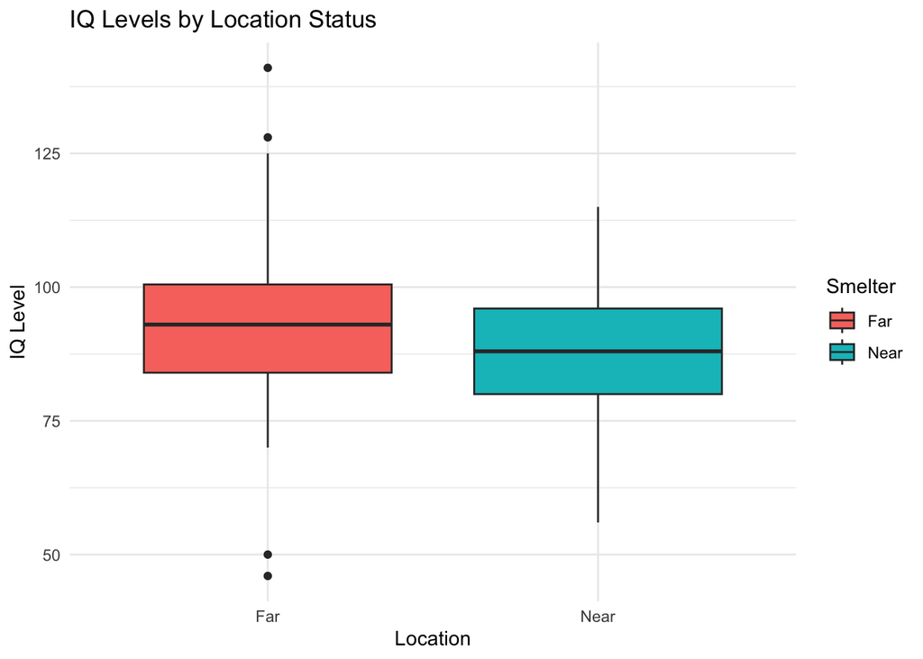

```r
ggplot(lead_data[lead_data$IQ < 999, ], aes(x = Smelter, y = IQ, fill = Smelter)) +
  geom_boxplot() +
  labs(title = "IQ Levels by Location Status",
       x = "Location",
       y = "IQ Level") +
  theme_minimal()
```

## Summary Table

```r
# Calculate summary statistics
summary_table <- lead_data %>%
  group_by(Smelter) %>%
  summarise(
    Mean_IQ = round(mean(IQ, na.rm = TRUE), 1),
    SD_IQ = round(sd(IQ, na.rm = TRUE), 1),
    Count = n()
  )

# Display the summary table
kable(summary_table, caption = "Summary Statistics for IQ Levels by Location Status")
```

Summary Statistics for IQ Levels by Location Status

| Smelter | Mean_IQ | SD_IQ | Count |
| --- | --- | --- | --- |
| Far | 92.7 | 16.0 | 67 |
| Near | 89.2 | 12.2 | 57 |

The table above provides a summary of IQ levels by location status, including the mean and standard deviation for each group. The sample sizes for both categories are similar. The average IQ for the “Near” group is 89.2, while the average IQ for the “Far” group is 92.7. After correcting the outlier in the “Far” group, the difference in average IQ between the two groups is less pronounced. This is reflected in both the boxplot and the summary table. To further compare the groups, a Wilcoxon test could be performed to assess whether the difference in IQ levels is statistically significant.